# Le format Markdown

20/05/2016

# Le format Markdown

## Présentation

Markdown est un langage de balisage léger créé par John Gruber en 2004. Son but est **d’offrir une syntaxe facile à lire et à écrire**.

[figure not shown]

Un document formaté selon Markdown devrait pouvoir être publié comme tel, en texte, sans donner l’impression qu’il a été marqué par des balises ou des instructions de formatage.

Un document rédigé en Markdown peut être converti facilement en HTML, PDF, ODT, EPUB etc …

Quelques liens :

- [Site officiel](http://daringfireball.net/projects/markdown/)
- [Le format Mardown](https://fr.wikipedia.org/wiki/Markdown)
- [La syntaxe](https://michelf.ca/projets/php-markdown/syntaxe/)
- [Test en ligne](https://michelf.ca/projets/php-markdown/banc-d'essai/)
- [Exemples](http://tvaira.free.fr/bts-sn/poo-c++/compte-rendu-tp/exemple-markdown.zip)

## Exemple

Exemple de fichier au format Markdown :

[figure not shown]

Après conversion en HTML :

[figure not shown]

## Pandoc sous Linux

Sous Linux, vous pouvez utiliser l’outil **pandoc** pour convertir un fichier au format Markdown dans de nombreux autres formats (HTML, PDF, ODT, EPUB etc … ). L’éditeur Geany propose un module de prévisualisation intégré.

Quelques conversions avec pandoc :

```
# format odt
$ pandoc --toc -o exemple.odt exemple.md

# format pdf
$ pandoc --toc -o exemple.pdf exemple.md

# format html
$ pandoc -s -S --toc -o exemple.html exemple.md
// avec une feuille de style externe
$ pandoc -s -S --toc -c exemple.css -A signature.html -o exemple.html exemple.md

# format epub
$ pandoc -S exemple.md -o exemple.epub
```

## Pandoc sous Windows

En ligne de commande (CLI) :

- [Pandoc](https://github.com/jgm/pandoc/releases/tag/1.17.0.2) et [Package Pandoc msi](https://github.com/fletcher/MultiMarkdown-5/releases)

Avec interface graphique (GUI) pour pandoc :

- [PanConvert](http://panconvert.sourceforge.net/) et [Package PanConvert msi](https://sourceforge.net/projects/panconvert/files/Newest/)

Plugin Word pour pandoc :

- [Writage](http://www.writage.com/) et [Package Writge msi](http://www.writage.com/Writage-1.8.3.msi)

Tests :

- Pandoc :

Installer pandoc-1.17.0.2-windows.msi

Lancer cmd.exe puis pandoc :

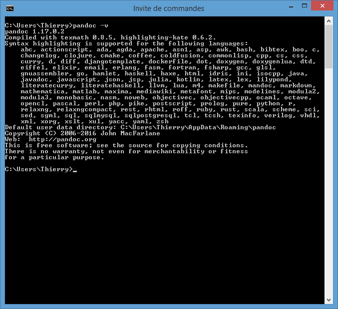

Voir les options de pandoc :

```
C:\Users\Thierry\Documents\markdown-windows>pandoc -h
```

Editer un document .md puis le convertir en HTML :

```
C:\Users\Thierry\Documents\markdown-windows>pandoc -s -S --toc -o markdown-windows.html markdown-windows.md
```

Et le convertir en .odt :

```
C:\Users\Thierry\Documents\markdown-windows>pandoc --toc -o markdown-windows.odt markdown-windows.md
```

- PanConvert :

Installer PanConvert-0.1.5-win32.msi

Lancer Panconvert.exe

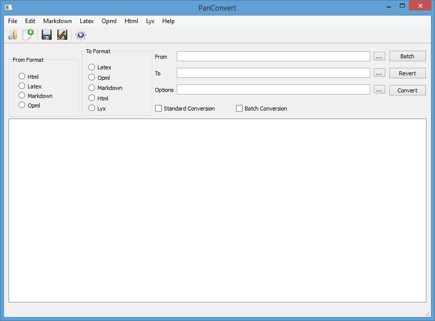

Edit -> Préferences pour configurer le chemin ver pandoc :

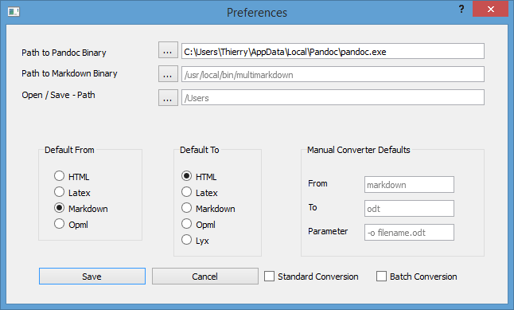

Ouvrir un fichier ou saisir un texte puis le convertir :

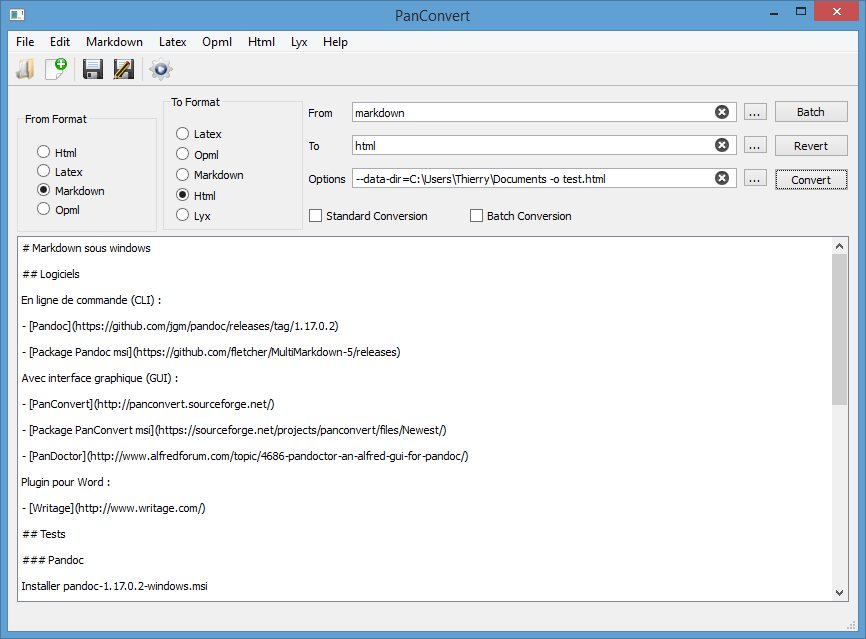

- Writage :

Installer Writage-1.8.3.msi

Lancer Word et ouvrir un document markdown :

[figure not shown]